# Analysis 2 - Predicting Seedling Growth using GLS

Carmen

February 28, 2017

### Step 1. Linear regression model with all possible variables, detect heterogeneity

```r
M1 <- lme(LastYearGrth.cm ~ Ht.cm + Cov1.2 + Ht1.2 + BasDia.cm + Genus + ShrG1, random = ~1|FirePatch, data= df)
anova(M1)
```

```
##             numDF denDF   F-value p-value
## (Intercept)     1   218 150.16136  <.0001
## Ht.cm           1   218 276.85009  <.0001
## Cov1.2          1   218  10.85842  0.0011
## Ht1.2           1   218   3.16564  0.0766
## BasDia.cm       1   218   1.85924  0.1741
## Genus           2   218   0.44678  0.6403
## ShrG1           6   218   1.04523  0.3969
```

```r
AIC(M1)
```

```
## [1] 1481.583
```

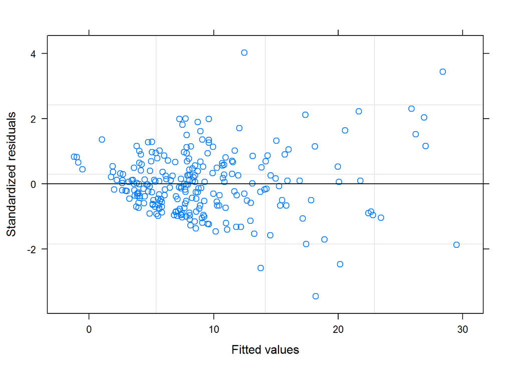

```r
plot(M1, which=c(1))
```

### Step 2. Refit with GLS

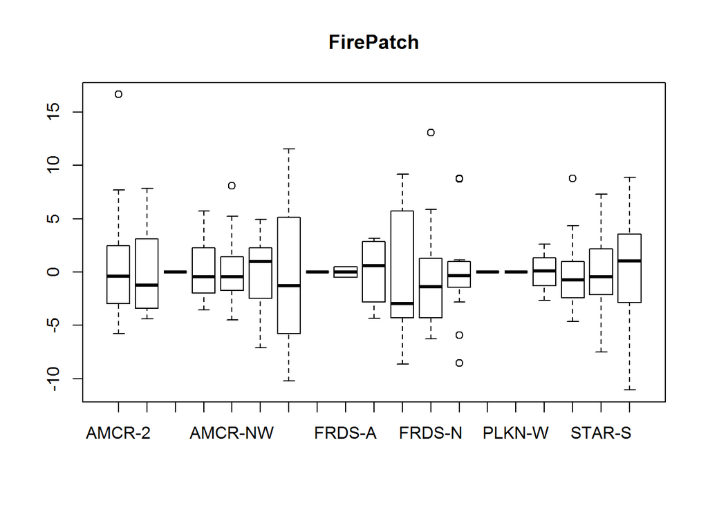

```r
M1.gls <- gls(LastYearGrth.cm ~ Ht.cm + Cov1.2 + Ht1.2 + BasDia.cm + Genus + ShrG1 + FirePatch, data= df)
E <- resid(M1.gls)
boxplot(E ~ df$FirePatch, main = "FirePatch")
```

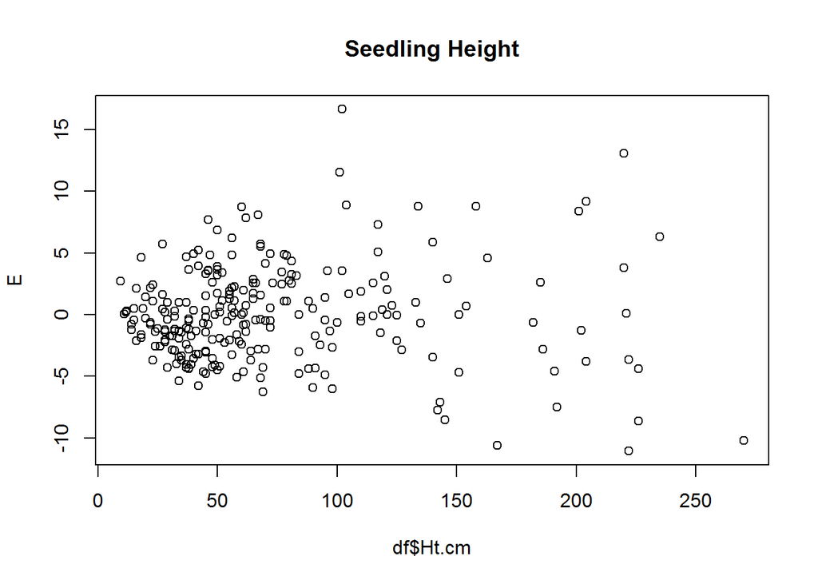

```r
plot(E ~ df$Ht.cm, main = "Seedling Height")
```

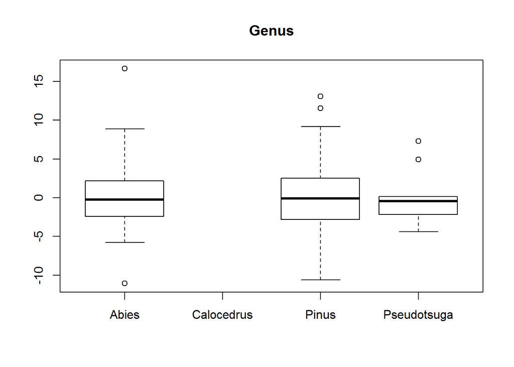

```r
boxplot(E ~ df$Genus, main = "Genus")
```

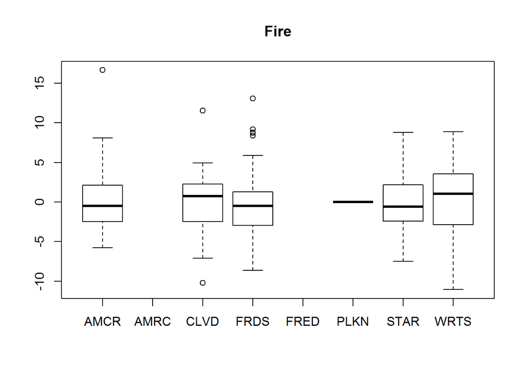

```r
boxplot(E ~ df$Fire, main = "Fire")
```

- It’s clear that the main source of heterogeneity is in the growth ~ height relationship, so include a GLS term based on height

### Step 3. Choose an appropriate variance structure. In this case, starting with varFixed and varPower based on seedling height

```r
library(nlme)
varFixed <- varFixed(~Ht.cm)
varPower <- varPower(form=~Ht.cm)
M1.fixed <- gls(LastYearGrth.cm ~ Ht.cm + Cov1.2 + Ht1.2 + BasDia.cm + Genus + ShrG1 + FirePatch,
                weights = varFixed,
                 data= df)
M1.power <- gls(LastYearGrth.cm ~ Ht.cm + Cov1.2 + Ht1.2 + BasDia.cm + Genus + ShrG1 + FirePatch,
                weights = varPower,
                 data= df)

anova(M1.fixed, M1.power)
```

```
##          Model df      AIC      BIC    logLik   Test  L.Ratio p-value
## M1.fixed     1 32 1338.155 1446.458 -637.0773
## M1.power     2 33 1330.922 1442.611 -632.4612 1 vs 2 9.232245  0.0024
```

```r
anova(M1.gls, M1.power)
```

```
##          Model df      AIC      BIC    logLik   Test  L.Ratio p-value
## M1.gls       1 32 1409.364 1517.668 -672.6820
## M1.power     2 33 1330.922 1442.611 -632.4612 1 vs 2 80.44158  <.0001
```

- varPower structure is better, at least before including random effect for patch

```r
M1.lme <- lme(LastYearGrth.cm ~ Ht.cm + Cov1.2 + Ht1.2 + BasDia.cm + Genus + ShrG1 + FirePatch,
                weights = varPower,
                random=~1|FirePatch,
                 data= df, method = "REML")
anova(M1.lme)
```

```
##             numDF denDF  F-value p-value
## (Intercept)     1   218 819.9854  <.0001
## Ht.cm           1   218 337.5815  <.0001
## Cov1.2          1   218   2.5950  0.1086
## Ht1.2           1   218   2.0974  0.1490
## BasDia.cm       1   218   0.6618  0.4168
## Genus           2   218   0.1679  0.8456
## ShrG1           6   218   0.5902  0.7380
## FirePatch      18     0   2.1372     NaN
```

```r
M2.lme <- lme(LastYearGrth.cm ~ Ht.cm + Cov1.2,
                weights = varPower,
                random=~1|Fire,
                 data= df, method = "ML")
anova(M2.lme)
```

```
##             numDF denDF   F-value p-value
## (Intercept)     1   241 133.25283  <.0001
## Ht.cm           1   241 288.97802  <.0001
## Cov1.2          1   241   0.25502   0.614
```

```r
M3.lme <- lme(LastYearGrth.cm ~ Ht.cm,
                weights = varPower,
                random=~1|Fire,
                 data= df, method = "ML")

anova(M2.lme, M3.lme)
```

```
##        Model df      AIC      BIC    logLik   Test   L.Ratio p-value
## M2.lme     1  6 1354.533 1375.638 -671.2664
## M3.lme     2  5 1352.780 1370.367 -671.3898 1 vs 2 0.2467149  0.6194
```

```r
M4.lme <- lme(LastYearGrth.cm ~ Ht.cm,
              random=~1|FirePatch,
                 data= df, method = "ML")

anova(M4.lme, M3.lme)
```

```
##        Model df     AIC      BIC    logLik   Test  L.Ratio p-value
## M4.lme     1  4 1476.72 1490.790 -734.3601
## M3.lme     2  5 1352.78 1370.367 -671.3898 1 vs 2 125.9406  <.0001
```

```r
M5.lme <- lme(LastYearGrth.cm ~ Ht.cm + Cov1.2,
                random=~1|Fire,
                 data= df, method = "ML")

summary(M5.lme)
```

```
## Linear mixed-effects model fit by maximum likelihood
##  Data: df
##        AIC      BIC    logLik
##   1481.224 1498.812 -735.6122
##
## Random effects:
##  Formula: ~1 | Fire
##         (Intercept) Residual
## StdDev:    1.814421   4.5498
##
## Fixed effects: LastYearGrth.cm ~ Ht.cm + Cov1.2
##                  Value Std.Error  DF   t-value p-value
## (Intercept)  2.6442306 1.4071200 241  1.879179  0.0614
## Ht.cm        0.1037567 0.0065402 241 15.864486  0.0000
## Cov1.2      -0.0031519 0.0013987 241 -2.253422  0.0251
##  Correlation:
##        (Intr) Ht.cm
## Ht.cm  -0.410
## Cov1.2 -0.656 -0.035
##
## Standardized Within-Group Residuals:
##        Min         Q1        Med         Q3        Max
## -5.0702534 -0.5724046 -0.1403417  0.5716409  3.8181123
##
## Number of Observations: 249
## Number of Groups: 6
```

```r
anova(M5.lme, M4.lme)
```

```
##        Model df      AIC      BIC    logLik   Test  L.Ratio p-value
## M5.lme     1  5 1481.224 1498.812 -735.6122
## M4.lme     2  4 1476.720 1490.790 -734.3601 1 vs 2 2.504287  0.1135
```

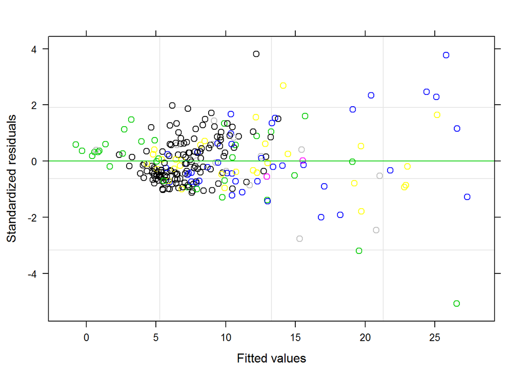

```r
plot(M5.lme, which=c(1),col=df$Fire, add.smooth=FALSE)
```

### Steps 4-6. Find optimal random structure

- Plot residuals vs. ht for each fire with and without GLS to see if you fixed the problem

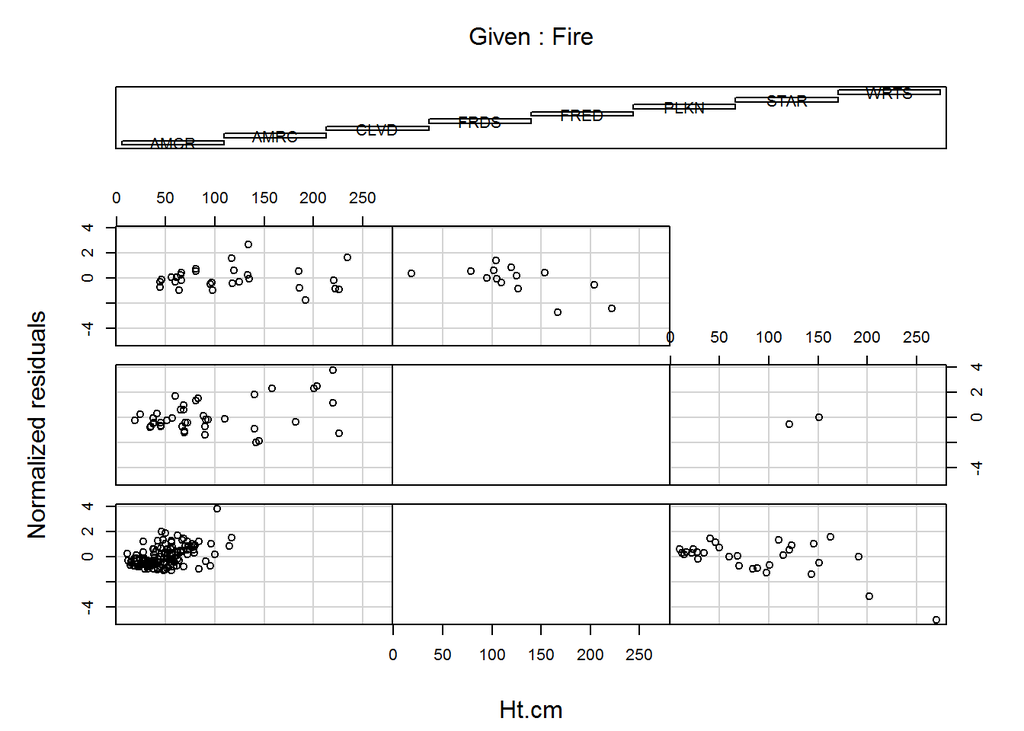

```r
E5 <- resid(M5.lme, type="normalized")
coplot(E5 ~ Ht.cm | Fire, data=df, ylab="Normalized residuals", main="Without GLS")
```

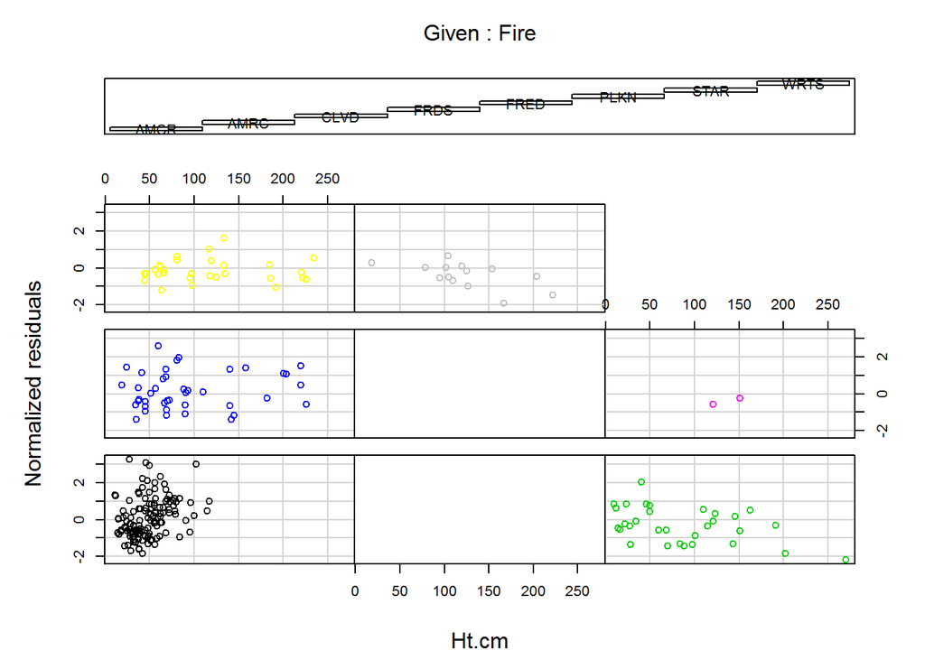

```r
E3 <- resid(M3.lme, type="normalized")
coplot(E3 ~ Ht.cm | Fire, data=df, ylab="Normalized residuals", main="VarPower", col=df$Fire)
```

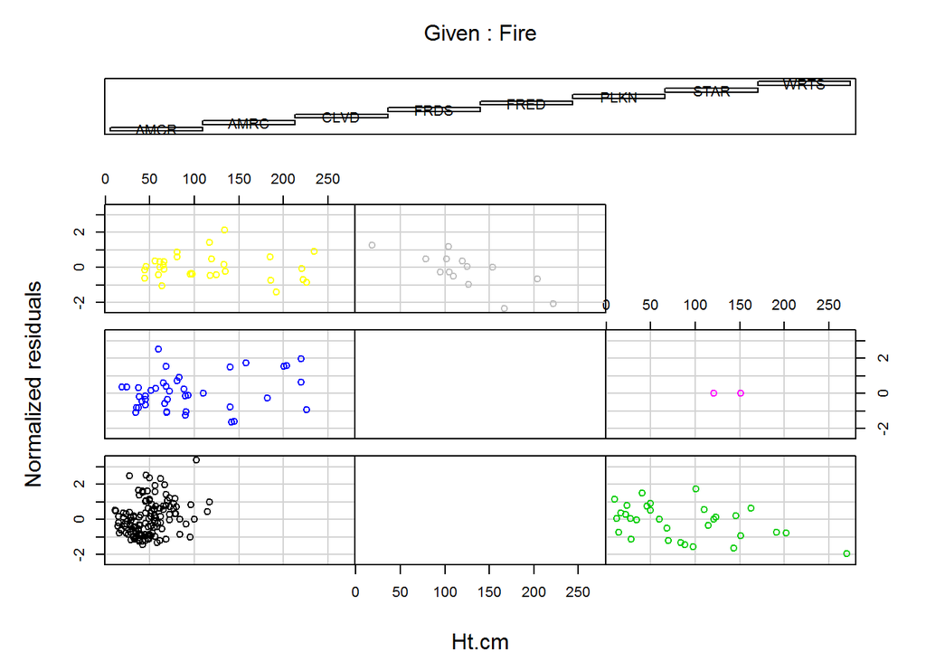

```r
E1.fixed <- resid(M1.fixed, type="normalized")
coplot(E1.fixed ~ Ht.cm | Fire, data=df, ylab="Normalized residuals", main="VarPower", col=df$Fire)
```

- Try to plot predicted values vs. shrub cover

```r
library(dplyr)
```

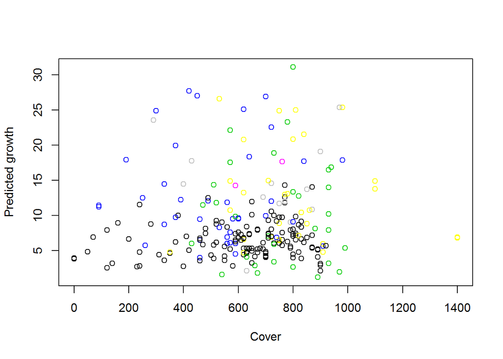

```r
pred <- as.data.frame(predict(M2.lme))
pred$Cov <- df$Cov1.2
pred$Ht.cm <- df$Ht.cm
pred$Fire <- df$Fire
#pred <- arrange(pred, predict(M3.lme))
plot(pred[,2], pred[,1],xlab="Cover",ylab="Predicted growth", col=pred$Fire)
```

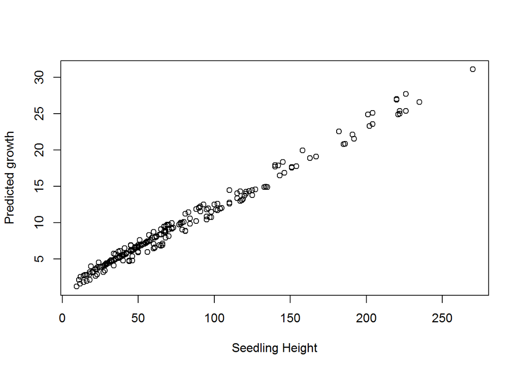

```r
plot(pred[,3], pred[,1],xlab="Seedling Height",ylab="Predicted growth")
```

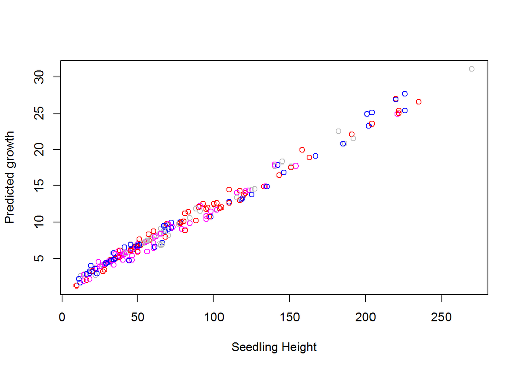

```r
plot(pred[,3], pred[,1],xlab="Seedling Height",ylab="Predicted growth",col=pred$Cov)
```

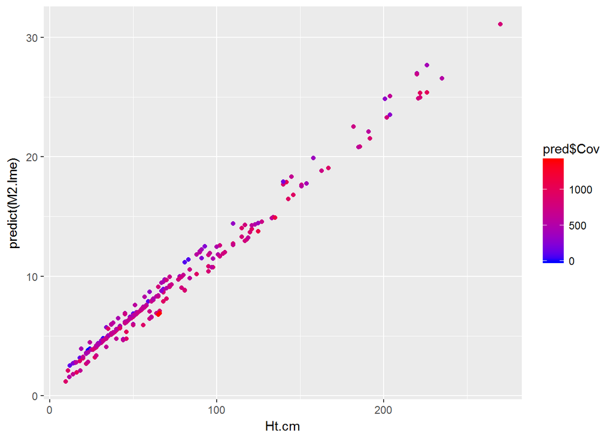

```r
library(ggplot2)
ggplot(pred)+
  geom_point(aes(y=predict(M2.lme),x=Ht.cm,col=pred$Cov))+
  scale_color_gradient(low="blue",high="red")
```

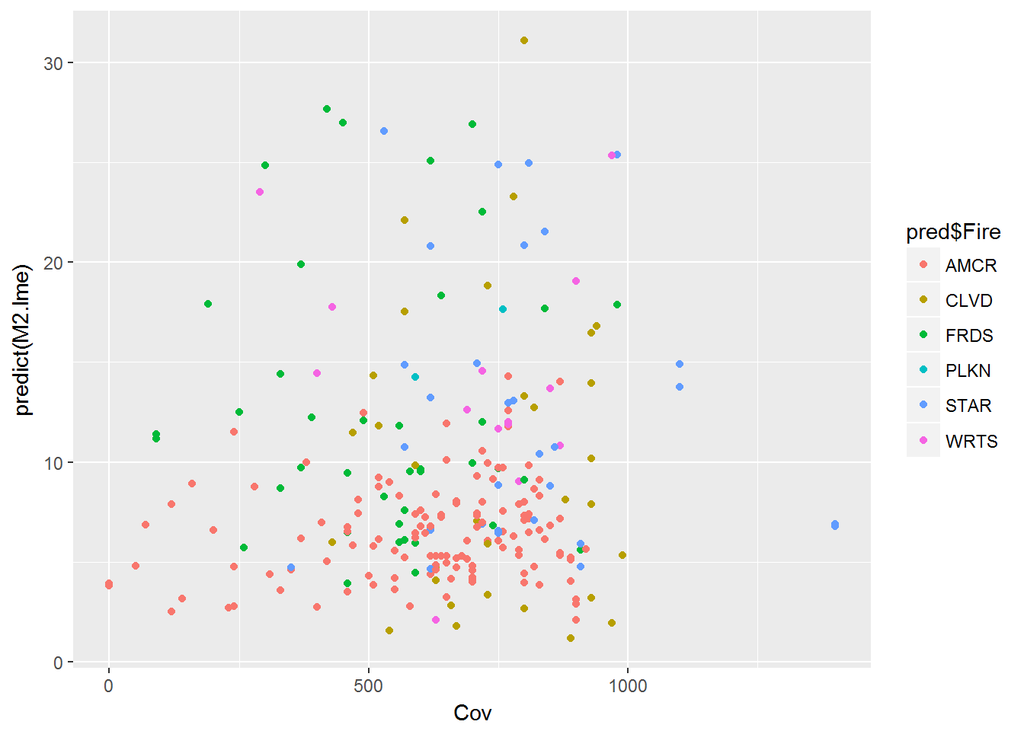

```r
ggplot(pred)+
  geom_point(aes(y=predict(M2.lme),x=Cov,col=pred$Fire))#+
```

```r
  scale_color_gradient(low="blue",high="red")
```

```
## <ScaleContinuous>
##  Range:
##  Limits:    0 --    1
```